# Sentimental Analysis

```python
from IPython.display import HTML
import random

def hide_toggle(for_next=False):
    this_cell = """$('div.cell.code_cell.rendered.selected')"""
    next_cell = this_cell + '.next()'

    toggle_text = 'Toggle show/hide'  # text shown on toggle link
    target_cell = this_cell  # target cell to control with toggle
    js_hide_current = ''  # bit of JS to permanently hide code in current cell (only when toggling next cell)

    if for_next:
        target_cell = next_cell
        toggle_text += ' next cell'
        js_hide_current = this_cell + '.find("div.input").hide();'

    js_f_name = 'code_toggle_{}'.format(str(random.randint(1,2**64)))

    html = """
        <script>
            function {f_name}() {{
                {cell_selector}.find('div.input').toggle();
            }}

            {js_hide_current}
        </script>

        <a href="javascript:{f_name}()">{toggle_text}</a>
    """.format(
        f_name=js_f_name,
        cell_selector=target_cell,
        js_hide_current=js_hide_current,
        toggle_text=toggle_text
    )

    return HTML(html)

hide_toggle()
```

Toggle show/hide

Helio is working with a government health agency to create a suite of smart phone medical apps for use by aid workers in developing countries. The government agency will be providing workers with technical support services, but they need to limit the support to a single model of smart phone and operating system.

**Objective**: to conduct a broad-based web sentiment analysis to gain insight into the attitudes toward 2 devices: Galaxy and iphone.

# Analysis

## Introduction and Dataset Information

**training datasets**: one iphone dataset and one galaxy dataset. They include the counts of relevant words (sentiment lexicons) for about 12,000 instances (web pages). The values in the device sentiment columns represents the overall sentiment toward the device on a scale of 0-5. The overall sentiment value has been manually input by a team of coworkers who read each webpage and rated the sentiment. The scale is as follows: **0: very negative** 1: negative **2: somewhat negative** 3: somewhat positive **4: positive** 5: very positive

**Attributes explanation examples**: iOS – counts mentions of iOS on a webpage

iphonecampos – counts positive sentiment mentions of the iphone camera (example: if the word "iphone camera" and "good" appeared on the same sentenced update the count with +1

galaxydisneg – counts negative sentiment mentions of the Galaxy display

htcperunc – counts the unclear sentiment mentions of HTC performance

**datasets to predict**: a matrix created collecting information from Common Crawl. To collect this information, It was taken into account the count of words associated towards devices features (camera, operative system, screen etc) within relevant documents on the web and the feeling towards these features ( positive, negative, uncertain). In order to conduct the analysis and to collect the large amounts of smart phone-related web pages, a cloud computing platform has been used ( AWS Elastic Map Reduce (EMR) platform to run a series of Hadoop Streaming jobs).

## Data Exploration and Feature Engineering

As first, an exploratory analysis has been run.  
Conclusion:

- no NAs
- classes are unbalanced (majority of the class have +4 or +5 in sentiment columns, which is our target variable)
- it's not have bene possible to define already a path or a logic between the count of words for each features of the smartphones and the sentiment. As en example, in the whole dataset, the word "galaxy" compare only 920 times ( in 920 observation). But still we find around 9000+ observation which has extremely positive sentiment towards Galaxy ( with score of 4+ and 5+). I would have expected that the sentiment towards the observation or websites would have be at the least "neutral" where Galaxy Smartphone is not mentioned, but this does not look the case as mentioned above. Since the filling of the sentiment columns have been a manual activity and since we take as assumption that not only logic but also feelings have driven the person/company to fill this document, we will take this information as reliable

**Libraries**

```python
import sys
import scipy
import numpy as np
import matplotlib
import pandas as pd
import sklearn
import seaborn as sns
import matplotlib.pyplot as plt
import plotly.graph_objects as go

from pandas import read_csv
from pandas.plotting import scatter_matrix
from numpy import array
from sklearn.model_selection import train_test_split
from sklearn.model_selection import cross_val_score
from sklearn.model_selection import KFold
from sklearn.metrics import classification_report
from sklearn.metrics import confusion_matrix
from sklearn.metrics import accuracy_score
from sklearn.linear_model import LogisticRegression
from sklearn.tree import DecisionTreeClassifier
from sklearn.neighbors import KNeighborsClassifier
from sklearn.discriminant_analysis import LinearDiscriminantAnalysis
from sklearn.naive_bayes import GaussianNB
from sklearn.svm import SVC
from sklearn.feature_selection import VarianceThreshold
from sklearn.ensemble import RandomForestClassifier
from sklearn.feature_selection import RFECV
from sklearn.metrics import r2_score
from rfpimp import permutation_importances
import warnings
warnings.simplefilter(action='ignore', category=FutureWarning)
from sklearn.feature_selection import SelectKBest, chi2, f_classif



hide_toggle()
```

Toggle show/hide

**Function to drop columns below a certain threshold**

```python
def variance_threshold_select(df, thresh):
    df1 = df.copy(deep=True) # Make a deep copy of the dataframe
    selector = VarianceThreshold(thresh)
    selector.fit(df1)
    df2 = df.loc[:,selector.get_support(indices=False)]

    return df2
hide_toggle()
```

Toggle show/hide

**Read Dataset**

```python
datasetIphone = pd.read_csv('iphone_smallmatrix_labeled_8d.csv')
datasetGalaxy = pd.read_csv('galaxy_smallmatrix_labeled_8d.csv')
hide_toggle()
```

Toggle show/hide

**Digging Information**

```python
datasetIphone.head(2)
hide_toggle()
```

Toggle show/hide

```python
datasetGalaxy.head(2)
hide_toggle()
```

Toggle show/hide

```python
datasetIphone.describe()
hide_toggle()
```

Toggle show/hide

```python
datasetGalaxy.describe()
hide_toggle()
```

Toggle show/hide

**Null Rows**

```python
datasetIphone.isnull().sum()
datasetGalaxy.isnull().sum()

hide_toggle()
```

Toggle show/hide

**Class Distribution Galaxy**

Toggle show/hide

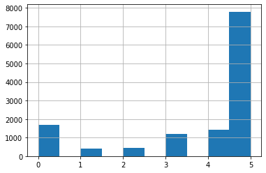

```python
datasetGalaxy.iloc[:,-1].hist()
hide_toggle()
```

**Class Distribution Iphone**

Toggle show/hide

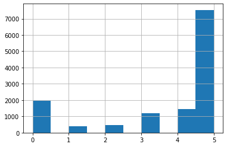

```python
datasetIphone.iloc[:,-1].hist()
hide_toggle()
```

### Correlation Analysys

As additional step to the analysis, a correlation matrix has been studied. First insights about the correlation amongst the variables:

- no highly correlated variable with the target variable ( max 0.30)
- a big amount of collinear variable which needs to be treated

Results:

- 5 variables have been excluded: 'htcdispos', 'nokiadisneg', 'nokiaperneg', 'nokiaperunc', 'googleperneg'

```python
corrMatrixGalaxy=datasetGalaxy.corr()
hide_toggle()
```

Toggle show/hide

Toggle show/hide

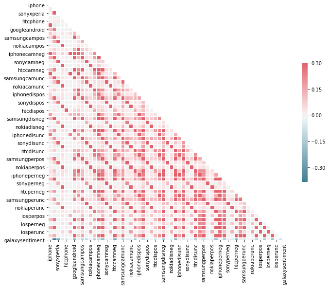

```python
mask = np.zeros_like(corrMatrixGalaxy, dtype=np.bool)
mask[np.triu_indices_from(mask)]= True

f, ax = plt.subplots(figsize=(11, 9))
cmap = sns.diverging_palette(220, 10, as_cmap=True)
sns.heatmap(corrMatrixGalaxy, mask=mask, cmap=cmap, vmax=.3, center=0,
            square=True, linewidths=.5, cbar_kws={"shrink": .5})
hide_toggle()
```

```python
lowerMatrix=corrMatrixGalaxy.where(np.triu(np.ones(corrMatrixGalaxy.shape), k=1).astype(np.bool))
bestFeatures=lowerMatrix.stack().sort_values(ascending=False)
hide_toggle()
```

Toggle show/hide

**Highest collinear variables**

```python
print(bestFeatures.head(5))
hide_toggle()
```

```
htcphone      htcdispos       0.977538
nokiadispos   nokiadisneg     0.964213
nokiacamunc   nokiaperunc     0.958152
googleperpos  googleperneg    0.957410
nokiaperpos   nokiaperneg     0.957014
dtype: float64
```

Toggle show/hide

```python
to_drop = [column for column in lowerMatrix.columns if any(lowerMatrix[column] > 0.95)]
```

**Dropped Collinear Variables**

```python
print(to_drop)
```

```
['htcdispos', 'nokiadisneg', 'nokiaperneg', 'nokiaperunc', 'googleperneg']
```

```python
datasetGalaxy.drop(datasetGalaxy[to_drop], axis=1)
hide_toggle()
```

Toggle show/hide

```python
pd.set_option('display.max_columns', None)
hide_toggle()
```

Toggle show/hide

### Near Zero Variance and Cumulative explained variance

**Zero or near zero variance variables indicate constant or close to constant predictors across all the samples. This kind of predictors are not really informative**

In order to select which are the variables to exclude the following steps have been followed:

**1. Find variance for each predictors**

**2. Calculate % variance/sum(variance) for each predictor**

**3. Plot the cumulative explained variance**

**4. Choose threeshold where a margina step would not bring any improvement to our models**

The analysis conducted led to three different breakpoint:

- 95% explained cumulative variance : 21 variables
- 98% explained cumulative variance: 30 variables
- 99% explained cumulative variance: 35 variables

The threeshold choosen is 95%. The reason behind this decision are the following:

- 3% of additional explained varinace does not justify the inclusion of additiona 9 variables in this case
- with additional analysis, such as recursive features elimination, the variables added to gain more variance explained are dropped. This would mean that the 3% of variance gained is stocastic

```python
metrics=datasetGalaxy.describe()
metrics=metrics.transpose()
metrics=metrics[:-1]
metrics['variance']=metrics['std']**2
totalVariance=metrics['variance'].sum(axis=0)
metrics['percentage']=metrics['variance']/totalVariance
orderedValues=metrics['percentage'].sort_values(ascending=False)

hide_toggle()
```

Toggle show/hide

```python
varianceToPlot=orderedValues.cumsum()
for i in range(len(varianceToPlot)):
    print("explained variance with ",i+1,"variables is", varianceToPlot[i],"%")

hide_toggle()
```

```
explained variance with  1 variables is 0.27000073894311344 %
explained variance with  2 variables is 0.427155553688085 %
explained variance with  3 variables is 0.5772755268058365 %
explained variance with  4 variables is 0.6480627323562175 %
explained variance with  5 variables is 0.7129743474595819 %
explained variance with  6 variables is 0.7532986378681265 %
explained variance with  7 variables is 0.7927821309514459 %
explained variance with  8 variables is 0.820071836178027 %
explained variance with  9 variables is 0.8435727347420966 %
explained variance with  10 variables is 0.8651129363254184 %
explained variance with  11 variables is 0.8781237020606458 %
explained variance with  12 variables is 0.8894934164525526 %
explained variance with  13 variables is 0.9000781243607494 %
explained variance with  14 variables is 0.9077111481690623 %
explained variance with  15 variables is 0.9147591148057055 %
explained variance with  16 variables is 0.9216303272814654 %
explained variance with  17 variables is 0.9280836288754868 %
explained variance with  18 variables is 0.9344744597052962 %
explained variance with  19 variables is 0.9403995021233664 %
explained variance with  20 variables is 0.9461919520416563 %
explained variance with  21 variables is 0.9511479398984414 %
explained variance with  22 variables is 0.9555720978325969 %
explained variance with  23 variables is 0.9598301979434692 %
explained variance with  24 variables is 0.9639709320857253 %
explained variance with  25 variables is 0.968051492315417 %
explained variance with  26 variables is 0.9716203763079884 %
explained variance with  27 variables is 0.974510593897411 %
explained variance with  28 variables is 0.97720030008874 %
explained variance with  29 variables is 0.9797528266780089 %
explained variance with  30 variables is 0.982118907822667 %
explained variance with  31 variables is 0.984123834574948 %
explained variance with  32 variables is 0.9860909873440699 %
explained variance with  33 variables is 0.9876225088184761 %
explained variance with  34 variables is 0.9889619495855181 %
explained variance with  35 variables is 0.9901152424535036 %
explained variance with  36 variables is 0.9910742960836555 %
explained variance with  37 variables is 0.9919595353128962 %
explained variance with  38 variables is 0.9927878672296844 %
explained variance with  39 variables is 0.9935778080688371 %
explained variance with  40 variables is 0.9943618014974471 %
explained variance with  41 variables is 0.9950492376432337 %
explained variance with  42 variables is 0.9957131226833696 %
explained variance with  43 variables is 0.9963542052324668 %
explained variance with  44 variables is 0.996901512824712 %
explained variance with  45 variables is 0.997337725008361 %
explained variance with  46 variables is 0.9977241747734336 %
explained variance with  47 variables is 0.9980725746131006 %
explained variance with  48 variables is 0.9984102151055224 %
explained variance with  49 variables is 0.998726484726085 %
explained variance with  50 variables is 0.9990090801911682 %
explained variance with  51 variables is 0.9992559269831652 %
explained variance with  52 variables is 0.9994802108207965 %
explained variance with  53 variables is 0.99966622779981 %
explained variance with  54 variables is 0.9998043009386695 %
explained variance with  55 variables is 0.9998678333654205 %
explained variance with  56 variables is 0.9999287707948801 %
explained variance with  57 variables is 0.999977987529913 %
explained variance with  58 variables is 1.0000000000000002 %
```

Toggle show/hide

Toggle show/hide

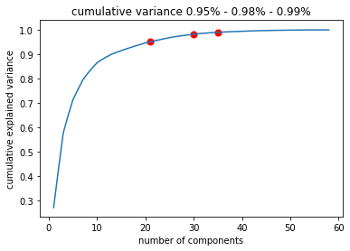

```python
plt.plot(np.arange(1,(len(varianceToPlot)+1)),varianceToPlot)
plt.xlabel('number of components')
plt.ylabel('cumulative explained variance')
plt.scatter(21, 0.9511479398984414, s=50, c='red')
plt.scatter(30, 0.982118907822667, s=50, c='red')
plt.scatter(35, 0.9901152424535036, s=50, c='red')
plt.title('cumulative variance 0.95% - 0.98% - 0.99%')

hide_toggle()
```

## Analysis

Specific analysis have been run for the two dataset. Whilst the first part is the same for both dataset because it does not involve the target variable, the following analysis is specific for each of dataset. Moreover, the analysis have been run to:

- dataset including variables which their cumulative explained variance is 95%
- dataset including variables which their cumulative explained variance is 98%

Both of them led to the same results since the additional variables used to explain the additional 3% will be dropped in the following analaysis.

**A brief description of the analysis run**:

- recursive feature elimination with cross validation: Recursive Feature Elimination(RFE) builds models to implement backwards selection of predictors based on predictor importance ranking. The least important predictors will be removed and the model will be re-built. The processe happens recursively untill the optimal subset of predictors are found. This subset can be used to produce an accurate model.
- permutation feature importance: similiar to the previous, Permutation feature importance is a model inspection technique.The permutation feature importance is defined to be the decrease in a model score when a single feature value is randomly shuffled. This procedure breaks the relationship between the feature and the target, moreover the drop in the model score is indicative of how much the model depends on the feature. This technique benefits from being model agnostic and can be calculated many times with different permutations of the feature.
- SelectKbest: the SelectKBest function scores the features using a function (in this case f_classif but could be others) and then removes all the variable except the highest scoring features".

The variable chosen are a mix of the ones given by the permutation feature importance and SelectKbest. To notice: it's been preferred using permutation feature importance since the recursive feature eliminiation, which is based on the impurity-based feature importance, can inflate the importance of numerical features (all of our variables are numerical).Furthermore, the impurity-based feature importance of random forests suffers from being computed on statistics derived from the training dataset: the importances can be high even for features that are not predictive of the target variable, as long as the model has the capacity to use them to overfit (this was not really our case - except that we don't see a real increase of accuracy using the recursive feature elimination from the 7th ranked onward)

### Galaxy Analysis

```python
datasetGalaxy['galaxysentiment'] = datasetGalaxy['galaxysentiment'].astype('category')
hide_toggle()
```

Toggle show/hide

```python
#95% dataframe
thresholdColumns=(varianceToPlot[varianceToPlot==(0.9511479398984414)])
thresholdValue=metrics.loc[thresholdColumns.index,"variance"]
dataframe095=variance_threshold_select(datasetGalaxy,thresholdValue.values)
hide_toggle()
```

Toggle show/hide

```python
#98% dataframe
thresholdColumns=(varianceToPlot[varianceToPlot==(0.982118907822667)])
thresholdValue=metrics.loc[thresholdColumns.index,"variance"]
dataframe098=variance_threshold_select(datasetGalaxy,thresholdValue.values)
hide_toggle()
```

Toggle show/hide

**Dataset Variance explained 95%**

#### Recursive feature elimination with cross-validation

```
Optimal number of features: 12
```

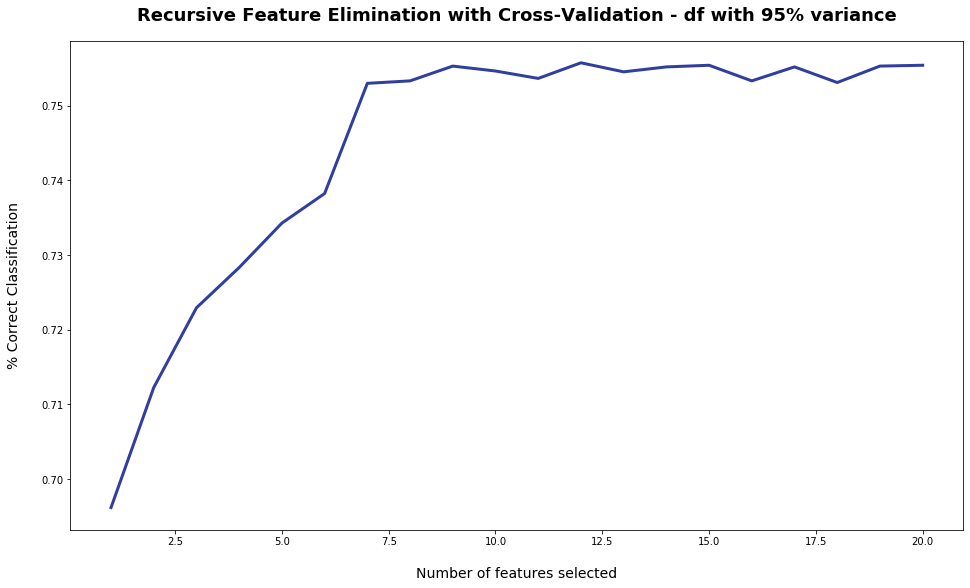

Toggle show/hide

```python
X_train, X_test, y_train, y_test = train_test_split(dataframe095.iloc[:,:-1], dataframe095.iloc[:,-1], test_size = 0.3, random_state = 123)
rfc = RandomForestClassifier(random_state=101)
rfecv = RFECV(estimator=rfc, step=1, cv=KFold(10), scoring='accuracy')
rfecv.fit(X_train, y_train)
print('Optimal number of features: {}'.format(rfecv.n_features_))

plt.figure(figsize=(16, 9))
plt.title('Recursive Feature Elimination with Cross-Validation - df with 95% variance', fontsize=18, fontweight='bold', pad=20)
plt.xlabel('Number of features selected', fontsize=14, labelpad=20)
plt.ylabel('% Correct Classification', fontsize=14, labelpad=20)
plt.plot(range(1, len(rfecv.grid_scores_) + 1), rfecv.grid_scores_, color='#303F9F', linewidth=3)

plt.show()
hide_toggle()
```

```python
bestX=X_train.copy(deep=True)
bestX.drop(bestX.columns[np.where(rfecv.support_ == False)[0]], axis=1, inplace=True)

dset = pd.DataFrame()
dset['attr'] = bestX.columns
dset['importance'] = rfecv.estimator_.feature_importances_

dset = dset.sort_values(by='importance', ascending=True)

fig = go.Figure(go.Bar(x=dset['importance'],y=dset['attr'], orientation='h'))
fig.show()

hide_toggle()
```

[interactive chart not shown]

Toggle show/hide

#### Permutation Feature Importance

```python
bestX=X_train.copy(deep=True)
```

```python
def r2(rf, X_train, y_train):
    return r2_score(y_train, rf.predict(X_train))

perm_imp_rfpimp = permutation_importances(rfc, X_train, y_train, r2)
perm_imp_rfpimp=perm_imp_rfpimp.sort_values(by='Importance')

print(perm_imp_rfpimp['Importance'].nlargest(10))

fig = go.Figure(go.Bar(x=perm_imp_rfpimp['Importance'],y=perm_imp_rfpimp.index, orientation='h'))
fig.show()
hide_toggle()
```

```
Feature
iphone          0.914518
iphoneperpos    0.184824
htcphone        0.145600
iphonedispos    0.127714
htccampos       0.113028
iphonedisunc    0.088301
iphonedisneg    0.076126
iphoneperneg    0.053659
iphoneperunc    0.039224
iphonecampos    0.034141
Name: Importance, dtype: float64
```

[interactive chart not shown]

Toggle show/hide

#### Feature Selection with Anova Test

```python
bestfeatures = SelectKBest(score_func=f_classif)
fit = bestfeatures.fit(X_train,y_train)
dfscores = pd.DataFrame(fit.scores_)
dfcolumns = pd.DataFrame(X_train.columns)
#concat two dataframes for better visualization
featureScores = pd.concat([dfcolumns,dfscores],axis=1)
featureScores.columns = ['Specs','Score']
featureScores= featureScores.dropna()
featureScores=featureScores.sort_values(by='Score')

hide_toggle()
```

Toggle show/hide

**Top features by F-Test**

```python
fig = go.Figure(go.Bar(x=featureScores['Score'],y=featureScores['Specs'], orientation='h'))
fig.show()
hide_toggle()
```

[interactive chart not shown]

Toggle show/hide

```python
print("Top 10 features by F-test")
print(featureScores.tail(10).sort_values(by='Score',ascending=False))
hide_toggle()
```

```
Top 10 features by F-test
           Specs       Score
2            ios  311.016606
0         iphone  310.769005
6   iphonecamunc  284.891465
5   iphonecamneg  184.054749
12  iphonedisunc  168.375761
17     htcperneg  126.900441
11     htcdisneg  101.291187
9   iphonedisneg   91.627291
15     htcperpos   84.782956
7   iphonedispos   77.794865
```

Toggle show/hide

```python
topVarImp=pd.Series((perm_imp_rfpimp['Importance'].nlargest(10)).index)
topFscore=featureScores.tail(10).sort_values(by='Score',ascending=False)['Specs']
hide_toggle()
```

Toggle show/hide

```python
predictors=pd.concat([topVarImp,topFscore])
predictors=predictors.drop_duplicates()
hide_toggle()
```

Toggle show/hide

```python
print("Best predictors combining F-Test and Permutation Feature Importance:\n")
print(predictors)
hide_toggle()
```

```
Best predictors combining F-Test and Permutation Feature Importance:

0           iphone
1     iphoneperpos
2         htcphone
3     iphonedispos
4        htccampos
5     iphonedisunc
6     iphonedisneg
7     iphoneperneg
8     iphoneperunc
9     iphonecampos
2              ios
6     iphonecamunc
5     iphonecamneg
17       htcperneg
11       htcdisneg
15       htcperpos
dtype: object
```

Toggle show/hide

```python
X_test=X_test.loc[:,predictors]
X_train=X_train.loc[:,predictors]
hide_toggle()
```

Toggle show/hide

#### Model Selection

```python
models = []
models.append(('LR', LogisticRegression(solver='liblinear', multi_class='ovr')))
models.append(('KNN', KNeighborsClassifier()))
models.append(('CART', DecisionTreeClassifier()))
models.append(('RF', RandomForestClassifier()))
models.append(('SVM', SVC(gamma='auto')))
# evaluate each model in turn
results = []
names = []
for name, model in models:

	kfold = KFold(n_splits=10, random_state=1, shuffle=True)
	cv_results = cross_val_score(model, X_train, y_train, cv=kfold, scoring='accuracy')
	results.append(cv_results)
	names.append(name)
	print('%s: %f (%f)' % (name, cv_results.mean(), cv_results.std()))

hide_toggle()
```

```
LR: 0.682743 (0.018992)
KNN: 0.711480 (0.088520)
CART: 0.739455 (0.014335)
RF: 0.754321 (0.015007)
SVM: 0.746392 (0.015304)
```

Toggle show/hide

Best candidates are RF and SVM

```python
model =  RandomForestClassifier()
model.fit(X_train, y_train)
predictions = model.predict(X_test)
print(accuracy_score(y_test, predictions))
print(confusion_matrix(y_test, predictions))
print(classification_report(y_test, predictions))
hide_toggle()
```

```
0.7515416238437821
[[ 378    0    4    2    3  113]
 [   0    0    1    0    1  113]
 [  23    0    1    0    5  112]
 [   2    0    1  142    3  209]
 [   8    1    1    6  136  277]
 [  19    3   17   12   31 2268]]
              precision    recall  f1-score   support

           0       0.88      0.76      0.81       500
           1       0.00      0.00      0.00       115
           2       0.04      0.01      0.01       141
           3       0.88      0.40      0.55       357
           4       0.76      0.32      0.45       429
           5       0.73      0.97      0.83      2350

    accuracy                           0.75      3892
   macro avg       0.55      0.41      0.44      3892
weighted avg       0.72      0.75      0.71      3892
```

Toggle show/hide

As we can see from the confusion matrix we never predict well for class such as 1 or 2. We also slightly tend to over-predict for class 5 which is the most numerous. In order to solve the first issue the classes will be combined in 3 unique classes: negative, average, positive

```python
y_train=y_train.replace(0,"negative")
y_train=y_train.replace(1, "negative")
y_train=y_train.replace(2, "average")
y_train=y_train.replace(3, "average")
y_train=y_train.replace(4, "positive")
y_train=y_train.replace(5, "positive")
hide_toggle()
```

Toggle show/hide

```python
y_test=y_test.replace(0,"negative")
y_test=y_test.replace(1,"negative")
y_test=y_test.replace(2,"average")
y_test=y_test.replace(3,"average")
y_test=y_test.replace(4,"positive")
y_test=y_test.replace(5,"positive")
hide_toggle()
```

Toggle show/hide

**Model evaluation**

As It's possible to see from the below accuracy matrix, an improvement in the metric have been achieved (even though the model bet much more for the positive class, which it will attempted to be adressed in the paragraph model improvement

```python
model =  RandomForestClassifier()
model.fit(X_train, y_train)
predictions = model.predict(X_test)
hide_toggle()
```

Toggle show/hide

```python
print(accuracy_score(y_test, predictions))
print(confusion_matrix(y_test, predictions))
print(classification_report(y_test, predictions))
hide_toggle()
```

```
0.8327338129496403
[[ 147   27  324]
 [   7  380  228]
 [  36   29 2714]]
              precision    recall  f1-score   support

     average       0.77      0.30      0.43       498
    negative       0.87      0.62      0.72       615
    positive       0.83      0.98      0.90      2779

    accuracy                           0.83      3892
   macro avg       0.83      0.63      0.68      3892
weighted avg       0.83      0.83      0.81      3892
```

Toggle show/hide

Toggle show/hide

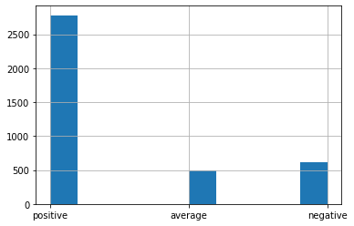

```python
y_test.hist()
hide_toggle()
```

#### Model improvement

In order to solve the class unbalance problem ,it has been attempted to change some parameters of the model (specifically weights).

After many attempts the model still tend to bet more for the positive class but the model achieved an improvement during the cross validation phase and keeping the same result on the test set.

```python
weights = {"positive":1, "average":2700/300 ,"negative":2700/400}
hide_toggle()
```

Toggle show/hide

**SVM MODEL - IMPROVEMENT ATTEMPT**

```python
model = SVC(gamma='scale', class_weight='balanced')
cv_results = cross_val_score(model, X_train, y_train, cv=kfold, scoring='accuracy')
print('%s: %f (%f)' % (name, cv_results.mean(), cv_results.std()))
hide_toggle()
```

```
SVM: 0.766215 (0.008055)
```

Toggle show/hide

```python
model.fit(X_train, y_train)
predictions = model.predict(X_test)
hide_toggle()
```

Toggle show/hide

```python
print(accuracy_score(y_test, predictions))
print(confusion_matrix(y_test, predictions))
print(classification_report(y_test, predictions))
hide_toggle()
```

```
0.7664439876670093
[[ 164   28  306]
 [  24  389  202]
 [ 282   67 2430]]
              precision    recall  f1-score   support

     average       0.35      0.33      0.34       498
    negative       0.80      0.63      0.71       615
    positive       0.83      0.87      0.85      2779

    accuracy                           0.77      3892
   macro avg       0.66      0.61      0.63      3892
weighted avg       0.76      0.77      0.76      3892
```

Toggle show/hide

**RF MODEL - IMPROVEMENT ATTEMPT**

```python
weights = {"positive":195, "average":500 ,"negative":900}
model = RandomForestClassifier(
            class_weight=weights)

cv_results = cross_val_score(model, X_train, y_train, cv=kfold, scoring='accuracy')
print('RF: %f (%f)' % ( cv_results.mean(), cv_results.std()))


hide_toggle()
```

```
RF: 0.824358 (0.014523)
```

Toggle show/hide

```python
model.fit(X_train, y_train)
predictions = model.predict(X_test)

hide_toggle()
```

Toggle show/hide

```python
print(accuracy_score(y_test, predictions))
print(confusion_matrix(y_test, predictions))
print(classification_report(y_test, predictions))
hide_toggle()
```

```
0.8309352517985612
[[ 148   27  323]
 [  10  377  228]
 [  38   32 2709]]
              precision    recall  f1-score   support

     average       0.76      0.30      0.43       498
    negative       0.86      0.61      0.72       615
    positive       0.83      0.97      0.90      2779

    accuracy                           0.83      3892
   macro avg       0.82      0.63      0.68      3892
weighted avg       0.83      0.83      0.81      3892
```

Toggle show/hide

#### Prediction on the Common Crawl Dataset

```python
matrixtoPredict=read_csv("MAtrix_forLazayPeople.csv")
```

```python
matrixtoPredict=matrixtoPredict.loc[:,predictors]
```

```python
predictionsGalaxy = model.predict(matrixtoPredict)
```

```python
predictionsGalaxy=pd.Series(predictionsGalaxy)
```

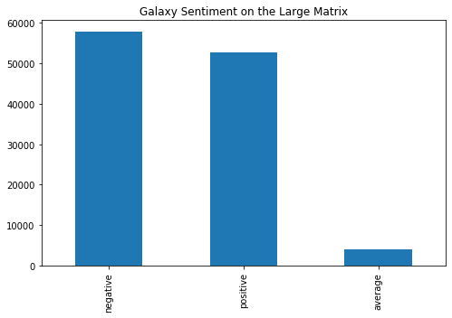

```python
predictionsGalaxy.value_counts().plot(kind='bar', figsize=(8,5))
plt.title ("Galaxy Sentiment on the Large Matrix")
plt.show()
```

### Iphone Analysis

**SAME ANALYSIS HAVE BEEN RUN FOR IPHONE**

```python
datasetIphone['iphonesentiment'] = datasetIphone['iphonesentiment'].astype('category')
```

```
Optimal number of features: 20
```

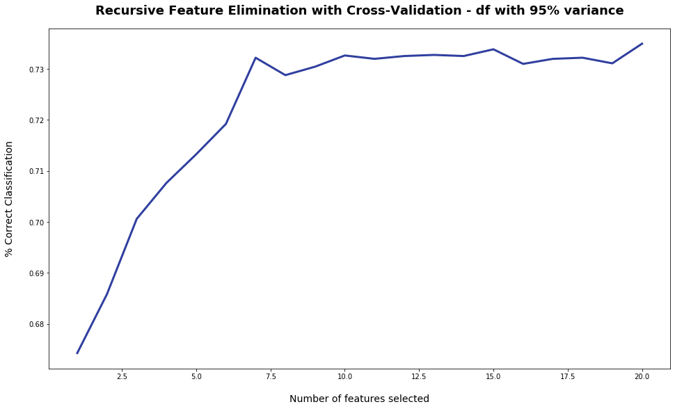

```python
X_train, X_test, y_train, y_test = train_test_split(dataframe095.iloc[:,:-1], datasetIphone['iphonesentiment'], test_size = 0.3, random_state = 123)
rfc = RandomForestClassifier(random_state=101)
rfecv = RFECV(estimator=rfc, step=1, cv=KFold(10), scoring='accuracy')
rfecv.fit(X_train, y_train)
print('Optimal number of features: {}'.format(rfecv.n_features_))

plt.figure(figsize=(16, 9))
plt.title('Recursive Feature Elimination with Cross-Validation - df with 95% variance', fontsize=18, fontweight='bold', pad=20)
plt.xlabel('Number of features selected', fontsize=14, labelpad=20)
plt.ylabel('% Correct Classification', fontsize=14, labelpad=20)
plt.plot(range(1, len(rfecv.grid_scores_) + 1), rfecv.grid_scores_, color='#303F9F', linewidth=3)

plt.show()
```

```python
def r2(rf, X_train, y_train):
    return r2_score(y_train, rf.predict(X_train))

perm_imp_rfpimp = permutation_importances(rfc, X_train, y_train, r2)
perm_imp_rfpimp=perm_imp_rfpimp.sort_values(by='Importance')

print(perm_imp_rfpimp['Importance'].nlargest(10))

fig = go.Figure(go.Bar(x=perm_imp_rfpimp['Importance'],y=perm_imp_rfpimp.index, orientation='h'))
fig.show()
```

```
Feature
iphone          0.813051
iphonedisneg    0.137896
htcphone        0.135159
htcdispos       0.098181
iphonedisunc    0.092416
iphoneperneg    0.090611
iphonedispos    0.084030
iphoneperunc    0.082866
iphoneperpos    0.078032
iphonecamunc    0.050080
Name: Importance, dtype: float64
```

[interactive chart not shown]

```python
bestfeatures = SelectKBest(score_func=f_classif)
fit = bestfeatures.fit(X_train,y_train)
dfscores = pd.DataFrame(fit.scores_)
dfcolumns = pd.DataFrame(X_train.columns)
#concat two dataframes for better visualization
featureScores = pd.concat([dfcolumns,dfscores],axis=1)
featureScores.columns = ['Specs','Score']
featureScores= featureScores.dropna()
featureScores=featureScores.sort_values(by='Score')
```

```python
print(featureScores)
fig = go.Figure(go.Bar(x=featureScores['Score'],y=featureScores['Specs'], orientation='h'))
fig.show()
```

```
            Specs       Score
10     sonydisneg    1.189921
1        htcphone    5.952708
8       htcdispos    7.937947
3    iphonecampos   14.835052
14  samsungperpos   18.533881
16   iphoneperneg   24.017391
19      htcperunc   27.110538
13   iphoneperpos   27.451996
4       htccampos   31.039296
18   iphoneperunc   62.234410
15      htcperpos   71.499802
7    iphonedispos   73.007548
11      htcdisneg   85.550795
9    iphonedisneg   86.470567
17      htcperneg  105.948634
12   iphonedisunc  161.932067
5    iphonecamneg  175.577485
6    iphonecamunc  280.050937
2             ios  300.433329
0          iphone  310.545778
```

[interactive chart not shown]

```python
featureScores.tail(10).sort_values(by='Score',ascending=False)
```

|  | Specs | Score |
| --- | --- | --- |
| 0 | iphone | 310.545778 |
| 2 | ios | 300.433329 |
| 6 | iphonecamunc | 280.050937 |
| 5 | iphonecamneg | 175.577485 |
| 12 | iphonedisunc | 161.932067 |
| 17 | htcperneg | 105.948634 |
| 9 | iphonedisneg | 86.470567 |
| 11 | htcdisneg | 85.550795 |
| 7 | iphonedispos | 73.007548 |
| 15 | htcperpos | 71.499802 |

```python
topVarImp=pd.Series((perm_imp_rfpimp['Importance'].nlargest(10)).index)
topFscore=featureScores.tail(10).sort_values(by='Score',ascending=False)['Specs']
```

```python
predictors=pd.concat([topVarImp,topFscore])
predictors=predictors.drop_duplicates()
```

```python
print(predictors)
```

```
0           iphone
1     iphonedisneg
2         htcphone
3        htcdispos
4     iphonedisunc
5     iphoneperneg
6     iphonedispos
7     iphoneperunc
8     iphoneperpos
9     iphonecamunc
2              ios
5     iphonecamneg
17       htcperneg
11       htcdisneg
15       htcperpos
dtype: object
```

```python
X_test=X_test.loc[:,predictors]
X_train=X_train.loc[:,predictors]
```

```python
models = []
models.append(('LR', LogisticRegression(solver='liblinear', multi_class='ovr')))
models.append(('KNN', KNeighborsClassifier()))
models.append(('CART', DecisionTreeClassifier()))
models.append(('RF', RandomForestClassifier()))
models.append(('SVM', SVC(gamma='auto')))
# evaluate each model in turn
results = []
names = []
for name, model in models:

	kfold = KFold(n_splits=10, random_state=1, shuffle=True)
	cv_results = cross_val_score(model, X_train, y_train, cv=kfold, scoring='accuracy')
	results.append(cv_results)
	names.append(name)
	print('%s: %f (%f)' % (name, cv_results.mean(), cv_results.std()))
```

```
LR: 0.659727 (0.018795)
KNN: 0.664347 (0.104234)
CART: 0.714789 (0.009681)
RF: 0.729655 (0.012696)
SVM: 0.721945 (0.014400)
```

```python
model =  RandomForestClassifier()
model.fit(X_train, y_train)
predictions = model.predict(X_test)
print(accuracy_score(y_test, predictions))
print(confusion_matrix(y_test, predictions))
print(classification_report(y_test, predictions))
```

```
0.7325282631038027
[[ 381    2    1    2    4  191]
 [   0    1    1    1    1  110]
 [  25    0    1    0    2  107]
 [   1    0    0  141    3  217]
 [   8    2    1    5  136  260]
 [  29    6    6   12   44 2191]]
              precision    recall  f1-score   support

           0       0.86      0.66      0.74       581
           1       0.09      0.01      0.02       114
           2       0.10      0.01      0.01       135
           3       0.88      0.39      0.54       362
           4       0.72      0.33      0.45       412
           5       0.71      0.96      0.82      2288

    accuracy                           0.73      3892
   macro avg       0.56      0.39      0.43      3892
weighted avg       0.71      0.73      0.69      3892
```

```python
y_train=y_train.replace(0,"negative")
y_train=y_train.replace(1, "negative")
y_train=y_train.replace(2, "average")
y_train=y_train.replace(3, "average")
y_train=y_train.replace(4, "positive")
y_train=y_train.replace(5, "positive")

y_test=y_test.replace(0,"negative")
y_test=y_test.replace(1,"negative")
y_test=y_test.replace(2,"average")
y_test=y_test.replace(3,"average")
y_test=y_test.replace(4,"positive")
y_test=y_test.replace(5,"positive")
```

```python
model =  RandomForestClassifier()
model.fit(X_train, y_train)
predictions = model.predict(X_test)
```

```python
print(accuracy_score(y_test, predictions))
print(confusion_matrix(y_test, predictions))
print(classification_report(y_test, predictions))
```

```
0.8119218910585817
[[ 144   26  327]
 [   5  380  310]
 [  26   38 2636]]
              precision    recall  f1-score   support

     average       0.82      0.29      0.43       497
    negative       0.86      0.55      0.67       695
    positive       0.81      0.98      0.88      2700

    accuracy                           0.81      3892
   macro avg       0.83      0.60      0.66      3892
weighted avg       0.82      0.81      0.79      3892
```

```python
matrixtoPredict=read_csv("MAtrix_forLazayPeople.csv")
matrixtoPredict=matrixtoPredict.loc[:,predictors]
```

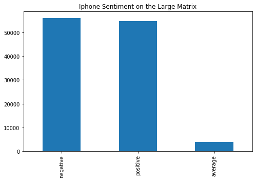

```python
predictionIphone=model.predict(matrixtoPredict)
predictionIphone=pd.Series(predictionIphone)
predictionIphone.value_counts().plot(kind='bar', figsize=(8,5))
plt.title ("Iphone Sentiment on the Large Matrix")
plt.show()
```

```python
datasetGalaxy.describe()
print("#iphone :", datasetGalaxy['iphone'].sum())
print("#galaxy:", datasetGalaxy['samsunggalaxy'].sum())
```

```
#iphone : 27867
#galaxy: 923
```

## Final Conclusion

As we can notice it's hard to understand if in the web it's prefered either iphone or samsung.

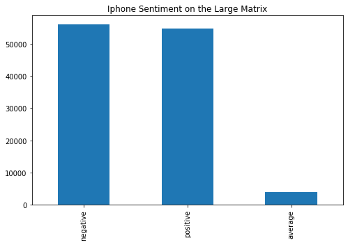

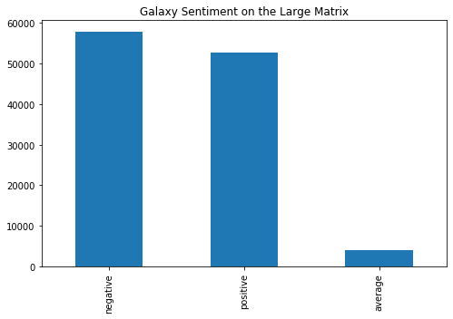

```python
predictionIphone.value_counts().plot(kind='bar', figsize=(8,5))
plt.title ("Iphone Sentiment on the Large Matrix")
plt.show()

predictionsGalaxy.value_counts().plot(kind='bar', figsize=(8,5))
plt.title ("Galaxy Sentiment on the Large Matrix")
plt.show()
```

**To notice:**

```python
datasetGalaxy.describe()
print("#iphone :", datasetGalaxy['iphone'].sum())
print("#galaxy:", datasetGalaxy['samsunggalaxy'].sum())
```

```
#iphone : 27867
#galaxy: 923
```

above we can find the sum of times that the word "galaxy" it has been find in the training test ( which is totally different of the word iphone). Whilst no opinion can be expressed by the the sentiment of the web comunity, It looks clear - at least from the training set taken in example - that samsung is not a popular choice - either for negative or positive reviews. And, as one famous local artist said: **Que hablen bien o mal, lo importante es que hablen [...] De los mediocres no habla nadie, y cuando lo hacen sólo dicen maravillas.**